# ENV H 570: Lab 3

Joan A. Casey

26 March, 2025

## Objective

The objective of this lab is to run a synthetic control model. We will leverage Dr. Brooke Anderson’s `hurricaneexposure` package and estimate the impact of hurricane exposure on mortality.

## Setup

```r
# Clear workspace of all objects and unload all extra (non-base) packages.
rm(list = ls(all = TRUE))
if (!is.null(sessionInfo()$otherPkgs)) {
  res <- suppressWarnings(
    lapply(paste('package:', names(sessionInfo()$otherPkgs), sep=""),
           detach, character.only=TRUE, unload=TRUE, force=TRUE))
}

# Load packages, installing if needed
if(!requireNamespace("pacman", quietly = TRUE)){
  install.packages("pacman")}
pacman::p_load(
  conflicted,
  here,
  weathermetrics,
  dplyr,
  tidyr,
  sf,
  ggplot2,
  MetBrewer,
  BiocManager,
  LowRankQP,
  Synth,
  drat # need this package to do the special install below
)

# Load packages that have to be pulled directly from github
# We will install and load the tidysynth & hurricaneexposure packages and dependencies
# also need to load hurricaneexposuredata in a specific way
pacman::p_load_gh("edunford/tidysynth")
pacman::p_load_gh("geanders/hurricaneexposure")
addRepo("geanders")
pacman::p_load("hurricaneexposuredata")

# Let's use conflict prefer again to make sure that we use these functions
# from the right package. We'll leave the instances of `hurricaneexposure::`
# since this package is new to you and we want you to see which functions come
# from it.
conflicts_prefer(dplyr::filter)
conflicts_prefer(dplyr::select)
conflicts_prefer(dplyr::mutate)
conflicts_prefer(dplyr::left_join)
```

## Load and clean data

### Hurricane data

```r
data("hurr_tracks")
glimpse(hurr_tracks)
```

```
## Rows: 5,503
## Columns: 6
## $ storm_id    <chr> "Alberto-1988", "Alberto-1988", "Alberto-1988", "Alberto-1…
## $ usa_atcf_id <chr> "AL011988", "AL011988", "AL011988", "AL011988", "AL011988"…
## $ date        <chr> "198808051800", "198808060000", "198808060600", "198808061…
## $ latitude    <dbl> 32.0, 32.8, 34.0, 35.2, 37.0, 38.7, 40.0, 41.5, 43.0, 45.0…
## $ longitude   <dbl> -77.5, -76.2, -75.2, -74.6, -73.5, -72.4, -70.8, -69.0, -6…
## $ wind        <dbl> 20, 20, 20, 25, 25, 25, 30, 35, 35, 35, 35, 30, 25, 25, 30…
```

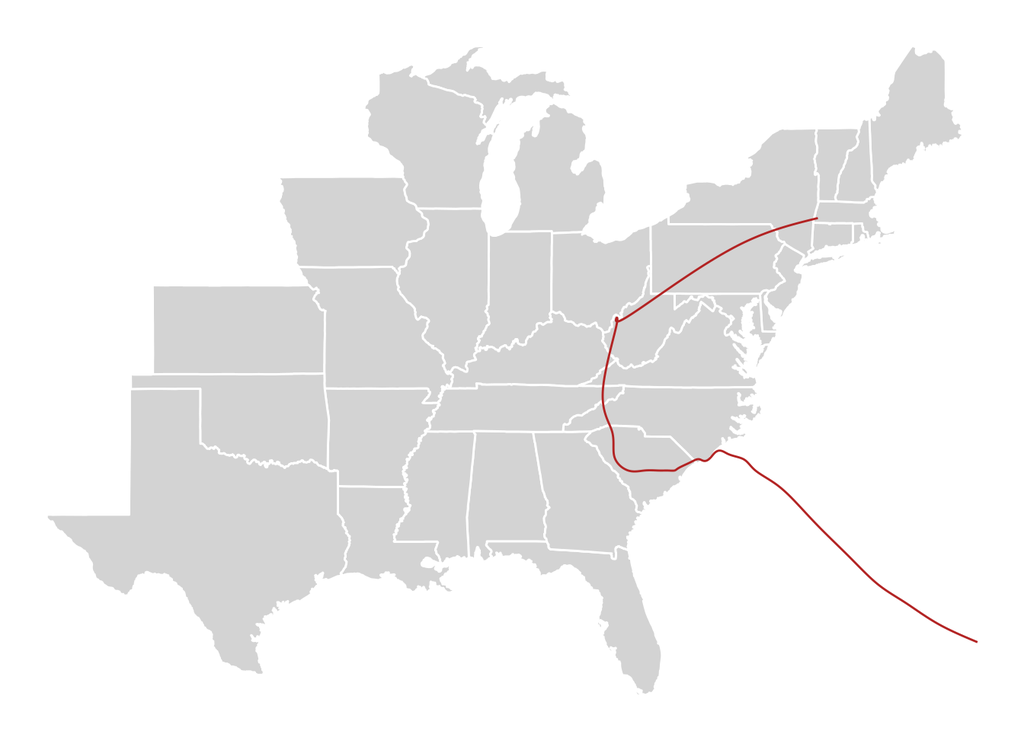

```r
# Visualize hurricane data
# Storm track
hurricaneexposure::map_tracks(storm = "Florence-2018")
```

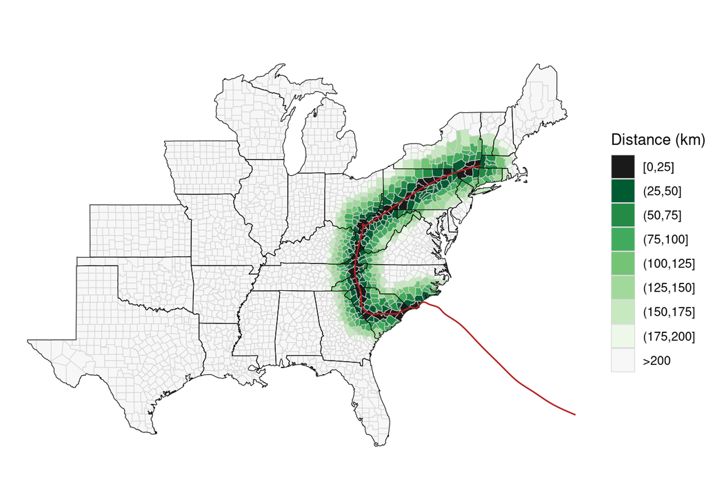

```r
# Distance from the storm track to the county
hurricaneexposure::map_counties(storm = "Florence-2018", metric = "distance")
```

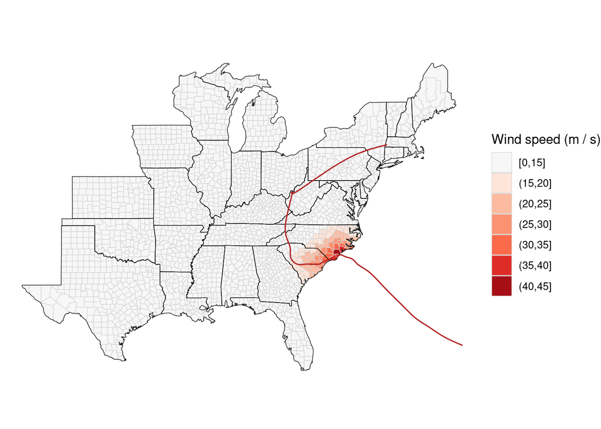

```r
# Estimated wind speed in the county
hurricaneexposure::map_counties(storm = "Florence-2018", metric = "wind")
```

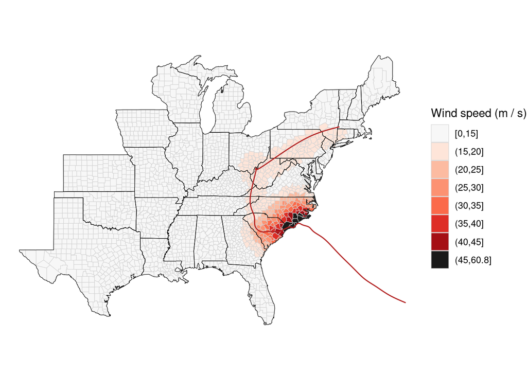

```r
# Estimated wind gusts in the county
hurricaneexposure::map_counties(storm = "Florence-2018", metric = "wind",
                                wind_var = "vmax_gust")
```

```r
# Distance from Hurricane
dist <- hurricaneexposure::filter_storm_data(
  storm = "Florence-2018", output_vars = c("fips", "closest_date", "storm_dist"))
dist <- dist %>% mutate(closest_date = as.Date(closest_date))
```

Let’s consider Onslow, NC as our exposed county. The FIPS code is 37133. Let’s also consider counties that are more than 200km from the storm as unexposed. Accordingly, we can subset our data to our one exposed county (Onslow) and our unexposed counties, from which we will construct our synthetic control.

```r
# Identifying counties located farther than 200 km (unexposed group)
dist <- dist %>% filter(fips=="37133" | storm_dist>200)

# Create binary exposed variable
dist <- dist %>% mutate(exposed = ifelse(fips=="37133", 1,0))

# Check data
table(dist$exposed) # 1 exposed county (Onslow)
```

```
##
##    0    1
## 1828    1
```

### All-cause mortality data

Now let’s bring in our outcome data. We’ll restrict to counties that are in our exposure data, as we don’t need outcome data for counties that do not have exposure data. Hurricane Florence occurred in 2018, so we’ll also filter to 2000-2018 since we don’t want years after our exposure included. Finally, let’s create a state fips code and a rate metric for our modeling step!

```r
mortality <- readRDS(here("data/lab/03/county_mortality.RDS"))

# Restrict to counties in dist dataframe
mortality <- mortality %>% filter(fips %in% dist$fips)

# Filter to before 2018 and after 1999
mortality <- mortality %>% filter(year>1999 & year<2019)

# # Filter to September (month of hurricane exposure in 2018)
mortality <- mortality %>% filter(month==9)

# Create state fips
mortality  <-  mortality %>% mutate(st_fips = substr(fips, 1, 2))

# Create a variable that is the death rate per 1,000
mortality <- mortality %>% mutate(death_rate = n_deaths/pop * 1000)
```

### Covariate data

Lastly, we will bring in our covariate data. For this analysis, we will use annual median income and unemployment data.

```r
covar <- readRDS(here("data/lab/03/income_unemp.rds"))
```

### Compile modeling dataset

```r
df_temp <- left_join(mortality, covar)
df <- left_join(df_temp, dist)
head(df)
```

| fips | year | month | n_deaths | pop | county_name | state_name | st_fips | death_rate | cnty_fips | med_inc | unemp | closest_date | storm_dist | exposed |
| --- | --- | --- | --- | --- | --- | --- | --- | --- | --- | --- | --- | --- | --- | --- |
| 01001 | 2000 | 9 | 25 | 44021 | Autauga | Alabama | 01 | 0.5679108 | NA | NA | NA | 2018-09-16 | 445.5831 | 0 |
| 01001 | 2001 | 9 | 17 | 44889 | Autauga | Alabama | 01 | 0.3787119 | 001 | 42183 | 4.1 | 2018-09-16 | 445.5831 | 0 |
| 01001 | 2002 | 9 | 14 | 45909 | Autauga | Alabama | 01 | 0.3049511 | 001 | 42841 | 4.8 | 2018-09-16 | 445.5831 | 0 |
| 01001 | 2003 | 9 | 28 | 46800 | Autauga | Alabama | 01 | 0.5982906 | 001 | 44241 | 5.0 | 2018-09-16 | 445.5831 | 0 |
| 01001 | 2004 | 9 | 24 | 48366 | Autauga | Alabama | 01 | 0.4962164 | 001 | 45379 | 4.7 | 2018-09-16 | 445.5831 | 0 |
| 01001 | 2005 | 9 | 36 | 49676 | Autauga | Alabama | 01 | 0.7246960 | 001 | 45019 | 3.8 | 2018-09-16 | 445.5831 | 0 |

## Synthetic control model

Now we are ready to build our modeling dataset! Let’s drop missing observations, restrict to only a few states for our eligible control counties (to make sure our run time is reasonable) and make sure we only have counties with a full time series of data (all years).

```r
# Get rid of missing data because we need complete dataset for this code to work
summary(df)
```

```
##      fips                year          month      n_deaths
##  Length:34448       Min.   :2000   Min.   :9   Min.   :   0.00
##  Class :character   1st Qu.:2004   1st Qu.:9   1st Qu.:  11.00
##  Mode  :character   Median :2009   Median :9   Median :  21.00
##                     Mean   :2009   Mean   :9   Mean   :  55.53
##                     3rd Qu.:2014   3rd Qu.:9   3rd Qu.:  44.00
##                     Max.   :2018   Max.   :9   Max.   :3705.00
##
##       pop          county_name         state_name          st_fips
##  Min.   :     89   Length:34448       Length:34448       Length:34448
##  1st Qu.:  12638   Class :character   Class :character   Class :character
##  Median :  25425   Mode  :character   Mode  :character   Mode  :character
##  Mean   :  81688
##  3rd Qu.:  58285
##  Max.   :5373418
##
##    death_rate      cnty_fips            med_inc           unemp
##  Min.   :0.0000   Length:34448       Min.   : 17201   Min.   : 1.700
##  1st Qu.:0.6202   Class :character   1st Qu.: 34588   1st Qu.: 4.400
##  Median :0.7493   Mode  :character   Median : 40798   Median : 5.700
##  Mean   :0.7837                      Mean   : 42396   Mean   : 6.263
##  3rd Qu.:0.9163                      3rd Qu.: 48058   3rd Qu.: 7.600
##  Max.   :3.0446                      Max.   :125635   Max.   :25.800
##                                      NA's   :1813     NA's   :1827
##   closest_date          storm_dist         exposed
##  Min.   :2018-09-13   Min.   :  48.54   Min.   :0.0000000
##  1st Qu.:2018-09-16   1st Qu.: 387.27   1st Qu.:0.0000000
##  Median :2018-09-17   Median : 733.23   Median :0.0000000
##  Mean   :2018-09-16   Mean   : 807.45   Mean   :0.0005516
##  3rd Qu.:2018-09-17   3rd Qu.:1128.09   3rd Qu.:0.0000000
##  Max.   :2018-09-18   Max.   :2243.50   Max.   :1.0000000
##
```

```r
df <- df %>% tidyr::drop_na(death_rate, unemp, med_inc)

# Look at the number of counties by state
table(df$state_name)
```

```
##
##        Alabama       Arkansas       Delaware        Florida        Georgia
##           1206           1350             54           1206           1710
##       Illinois        Indiana           Iowa         Kansas       Kentucky
##           1836           1656           1782           1890           1296
##      Louisiana          Maine       Maryland  Massachusetts       Michigan
##           1138            288            252             72           1494
##    Mississippi       Missouri  New Hampshire     New Jersey       New York
##           1476           2070             90            144            198
## North Carolina           Ohio       Oklahoma   Pennsylvania      Tennessee
##            522            720           1386             18           1242
##          Texas        Vermont       Virginia      Wisconsin
##           4555            180           1494           1296
```

```r
#Confirm exposed county in the dataframe
df %>% filter(exposed==1)
```

| fips | year | month | n_deaths | pop | county_name | state_name | st_fips | death_rate | cnty_fips | med_inc | unemp | closest_date | storm_dist | exposed |
| --- | --- | --- | --- | --- | --- | --- | --- | --- | --- | --- | --- | --- | --- | --- |
| 37133 | 2001 | 9 | 52 | 151068 | Onslow | North Carolina | 37 | 0.3442158 | 133 | 33448 | 5.5 | 2018-09-14 | 48.5352 | 1 |
| 37133 | 2002 | 9 | 38 | 153397 | Onslow | North Carolina | 37 | 0.2477232 | 133 | 33504 | 6.8 | 2018-09-14 | 48.5352 | 1 |
| 37133 | 2003 | 9 | 63 | 150481 | Onslow | North Carolina | 37 | 0.4186575 | 133 | 33108 | 6.8 | 2018-09-14 | 48.5352 | 1 |
| 37133 | 2004 | 9 | 76 | 158837 | Onslow | North Carolina | 37 | 0.4784779 | 133 | 34995 | 5.8 | 2018-09-14 | 48.5352 | 1 |
| 37133 | 2005 | 9 | 63 | 157205 | Onslow | North Carolina | 37 | 0.4007506 | 133 | 39942 | 5.7 | 2018-09-14 | 48.5352 | 1 |
| 37133 | 2006 | 9 | 72 | 161185 | Onslow | North Carolina | 37 | 0.4466917 | 133 | 38478 | 4.8 | 2018-09-14 | 48.5352 | 1 |
| 37133 | 2007 | 9 | 71 | 163256 | Onslow | North Carolina | 37 | 0.4348998 | 133 | 41799 | 4.8 | 2018-09-14 | 48.5352 | 1 |
| 37133 | 2008 | 9 | 60 | 169059 | Onslow | North Carolina | 37 | 0.3549057 | 133 | 46186 | 5.7 | 2018-09-14 | 48.5352 | 1 |
| 37133 | 2009 | 9 | 60 | 173064 | Onslow | North Carolina | 37 | 0.3466926 | 133 | 41161 | 8.8 | 2018-09-14 | 48.5352 | 1 |
| 37133 | 2010 | 9 | 60 | 186918 | Onslow | North Carolina | 37 | 0.3209964 | 133 | 41969 | 8.2 | 2018-09-14 | 48.5352 | 1 |

[output cut: 8 more lines]

```r
# Also going to restrict to counties in Georgia, Maryland, Virginia
# because model takes too long to run
df <- df %>% filter(
  state_name == "Georgia" |
    state_name == "Maryland" |
    state_name == "Virginia" |
    fips=="37133" ) #Need to keep county of interest that is outside of TX, MO, NC

# Just keep needed variables
df <- df %>% select(fips, year, death_rate, unemp, med_inc)

# Also need counties to have complete years
df <- df %>% group_by(fips) %>% mutate(n=n())
table(df$n)
```

```
##
##   18
## 3474
```

```r
table(df$year)
```

```
##
## 2001 2002 2003 2004 2005 2006 2007 2008 2009 2010 2011 2012 2013 2014 2015 2016
##  193  193  193  193  193  193  193  193  193  193  193  193  193  193  193  193
## 2017 2018
##  193  193
```

```r
df <- df %>% filter(n==18) # just keeping counties with data in all 18 years
```

### Run synthetic control

Now we can run our model! This may take about 10-15 minutes, so make sure you stay connected to the internet and your R session.

```r
model <-
  df %>%
  # initial the synthetic control object
  synthetic_control(
    outcome = death_rate,
    # outcome
    unit = fips,
    # unit index in the panel data
    time = year,
    # time index in the panel data
    i_unit = "37133",
    # unit where the intervention occurred
    i_time = 2018,
    # time period when the intervention occurred
    generate_placebos = T # generate placebo synthetic controls (for inference)
  ) %>%

  # Generate the aggregate predictors used to fit the weights
  generate_predictor(
    time_window = 2000:2018,
    mmed_inc = mean(med_inc, na.rm = T),
    muemply = mean(unemp, na.rm = T)
  ) %>%

  # Lagged mortality
  generate_predictor(time_window = 2000,
                     death_2000 = death_rate) %>%
  generate_predictor(time_window = 2001,
                     death_2001 = death_rate) %>%
  generate_predictor(time_window = 2002,
                     death_2002 = death_rate) %>%
  generate_predictor(time_window = 2003,
                     death_2003 = death_rate) %>%
  generate_predictor(time_window = 2004,
                     death_2004 = death_rate) %>%
  generate_predictor(time_window = 2005,
                     death_2005 = death_rate) %>%
  generate_predictor(time_window = 2006,
                     death_2006 = death_rate) %>%
  generate_predictor(time_window = 2007,
                     death_2007 = death_rate) %>%
  generate_predictor(time_window = 2008,
                     death_2008 = death_rate) %>%
  generate_predictor(time_window = 2009,
                     death_2009 = death_rate) %>%
  generate_predictor(time_window = 2010,
                     death_2010 = death_rate) %>%
  generate_predictor(time_window = 2011,
                     death_2011 = death_rate) %>%
  generate_predictor(time_window = 2012,
                     death_2012 = death_rate) %>%
  generate_predictor(time_window = 2013,
                     death_2013 = death_rate) %>%
  generate_predictor(time_window = 2014,
                     death_2014 = death_rate) %>%
  generate_predictor(time_window = 2015,
                     death_2015 = death_rate) %>%
  generate_predictor(time_window = 2016,
                     death_2016 = death_rate) %>%
  generate_predictor(time_window = 2017,
                     death_2017 = death_rate) %>%


  # Generate the fitted weights for the synthetic control
  generate_weights(optimization_window = 2000:2018,
                   margin_ipop = .02, sigf_ipop = 7, bound_ipop = 6) %>% # time to use in the optimization task

  # Generate the synthetic control
  generate_control()
```

If this code runs too slowly and never finishes, you can also read in the model results from the rds file on Canvas. You can comment out or delete the model above and instead pull in model results that we ran and saved. You will need to download the file and upload it to the server using the upload button under `Files`. Make sure you read it from the filepath where you upload it!

```r
# model <- readRDS("~/synth_control_results.rds")
```

## Plotting and model diagnostics

Let’s take a look at our model.

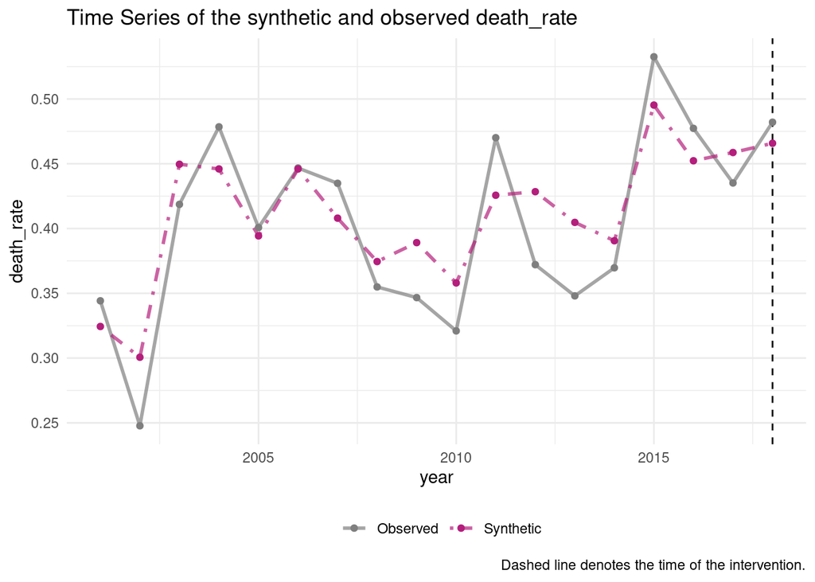

```r
# Plot Onslow County over time versus other counties included
model %>% plot_trends()
```

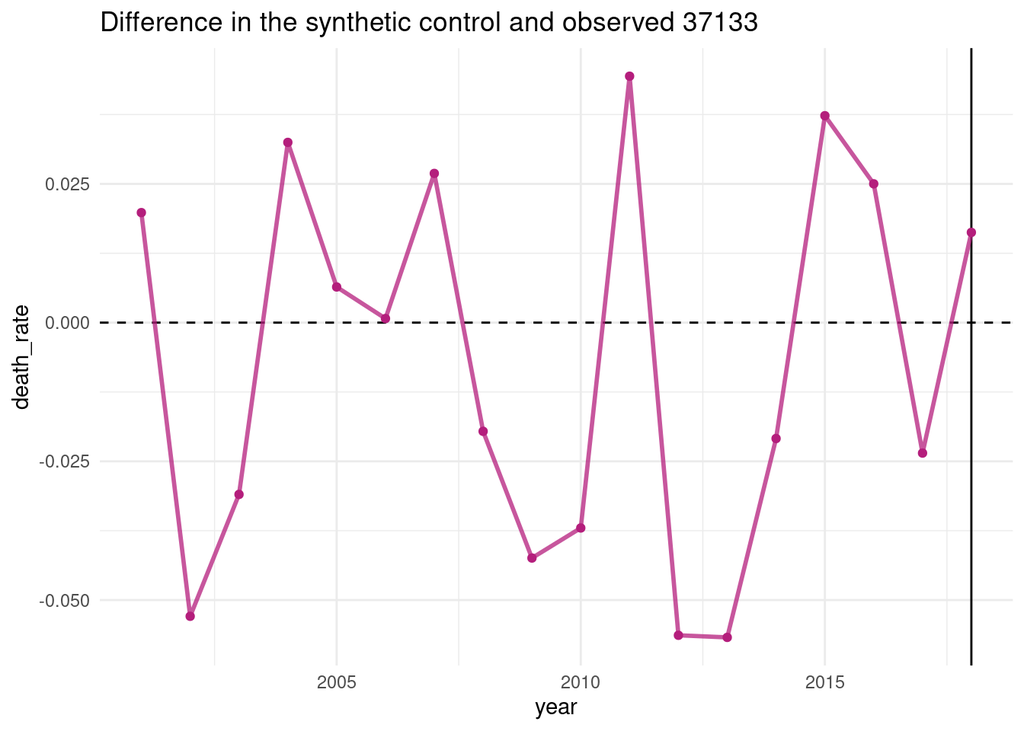

```r
# Plot differences in counties over time
model %>% plot_differences()
```

```r
# How balanced were we after implementing the synthetic control?
model %>% grab_balance_table()
```

| variable | 37133 | synthetic_37133 | donor_sample |
| --- | --- | --- | --- |
| mmed_inc | 4.218200e+04 | 8.101293e+04 | 4.630892e+04 |
| muemply | 6.322222e+00 | 4.262091e+00 | 6.355006e+00 |
| death_2001 | 3.442158e-01 | 3.243897e-01 | 5.975340e-01 |
| death_2002 | 2.477232e-01 | 3.006465e-01 | 6.087943e-01 |
| death_2003 | 4.186575e-01 | 4.496202e-01 | 7.463357e-01 |
| death_2004 | 4.784779e-01 | 4.459982e-01 | 7.208769e-01 |
| death_2005 | 4.007506e-01 | 3.943280e-01 | 7.367586e-01 |
| death_2006 | 4.466917e-01 | 4.459591e-01 | 7.144844e-01 |
| death_2007 | 4.348998e-01 | 4.080122e-01 | 7.499820e-01 |
| death_2008 | 3.549057e-01 | 3.744954e-01 | 6.942690e-01 |

[output cut: 9 more lines]

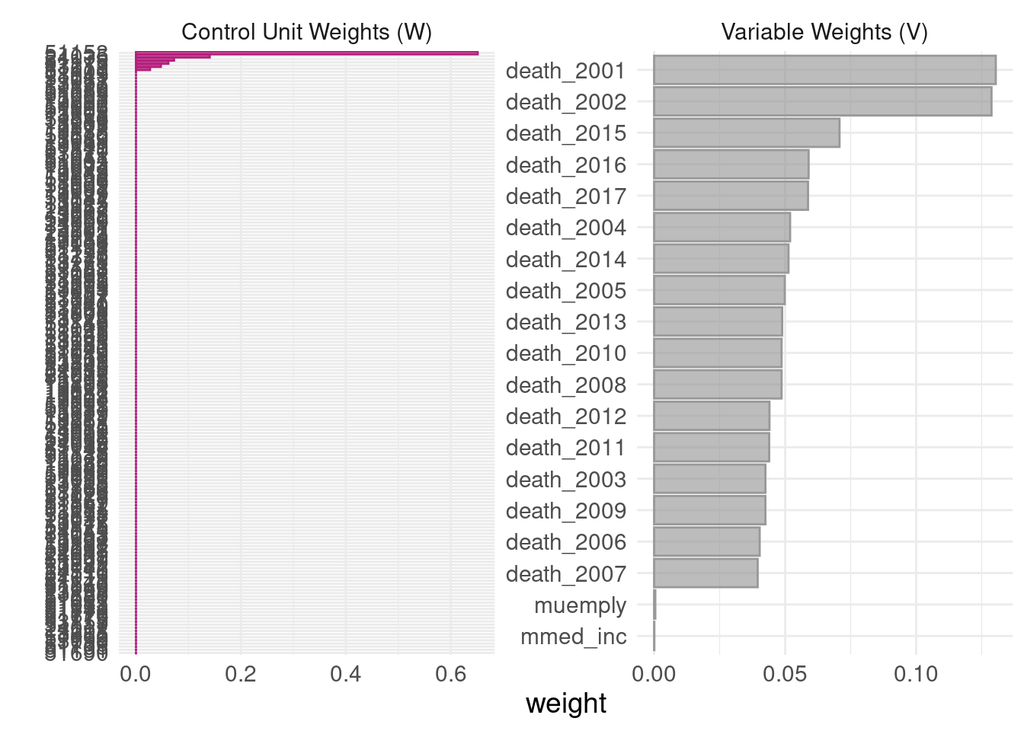

```r
# Which of our (limited) variables contributed most?
model %>% plot_weights()
```

```r
# Which counties contribute most to the synthetic control?
weights <- model %>% grab_unit_weights()
weights
```

| unit | weight |
| --- | --- |
| 13001 | 5.551629e-10 |
| 13003 | 4.386874e-09 |
| 13005 | 1.021141e-09 |
| 13007 | 1.334531e-09 |
| 13015 | 3.452774e-10 |
| 13017 | 2.704190e-10 |
| 13019 | 3.850696e-10 |
| 13023 | 4.088371e-10 |
| 13025 | 1.128951e-09 |
| 13027 | 2.730975e-10 |

[output cut: 182 more lines]